# PRA 2: Creació de la visualització

**Nom i cognoms: Montse Sanahuja Mateu** **Correu: msanahujamateu@uoc.edu**

```python
import numpy as np
import pandas as pd
import seaborn as sns

import matplotlib.pyplot as plt

%matplotlib inline
```

# 1. Càrrega del conjunt de dades

Primer de tot carregarem el conjunt de dades "heart_disease_health_indicators_BRFSS2015" i les revisarem.

```python
data = pd.read_csv('heart_disease_health_indicators_BRFSS2015.csv')
```

```python
data.head()
```

|  | HeartDiseaseorAttack | HighBP | HighChol | CholCheck | BMI | Smoker | Stroke | Diabetes | PhysActivity | Fruits | Veggies | HvyAlcoholConsump | AnyHealthcare | NoDocbcCost | GenHlth | MentHlth | PhysHlth | DiffWalk | Sex | Age | Education | Income |
| --- | --- | --- | --- | --- | --- | --- | --- | --- | --- | --- | --- | --- | --- | --- | --- | --- | --- | --- | --- | --- | --- | --- |
| 0 | 0.0 | 1.0 | 1.0 | 1.0 | 40.0 | 1.0 | 0.0 | 0.0 | 0.0 | 0.0 | 1.0 | 0.0 | 1.0 | 0.0 | 5.0 | 18.0 | 15.0 | 1.0 | 0.0 | 9.0 | 4.0 | 3.0 |
| 1 | 0.0 | 0.0 | 0.0 | 0.0 | 25.0 | 1.0 | 0.0 | 0.0 | 1.0 | 0.0 | 0.0 | 0.0 | 0.0 | 1.0 | 3.0 | 0.0 | 0.0 | 0.0 | 0.0 | 7.0 | 6.0 | 1.0 |
| 2 | 0.0 | 1.0 | 1.0 | 1.0 | 28.0 | 0.0 | 0.0 | 0.0 | 0.0 | 1.0 | 0.0 | 0.0 | 1.0 | 1.0 | 5.0 | 30.0 | 30.0 | 1.0 | 0.0 | 9.0 | 4.0 | 8.0 |
| 3 | 0.0 | 1.0 | 0.0 | 1.0 | 27.0 | 0.0 | 0.0 | 0.0 | 1.0 | 1.0 | 1.0 | 0.0 | 1.0 | 0.0 | 2.0 | 0.0 | 0.0 | 0.0 | 0.0 | 11.0 | 3.0 | 6.0 |
| 4 | 0.0 | 1.0 | 1.0 | 1.0 | 24.0 | 0.0 | 0.0 | 0.0 | 1.0 | 1.0 | 1.0 | 0.0 | 1.0 | 0.0 | 2.0 | 3.0 | 0.0 | 0.0 | 0.0 | 11.0 | 5.0 | 4.0 |

# 2. Quines variables tenen més correlació amb la variable HeartDiseaseorAttack? Aquesta correlació és ascendent o descendent?

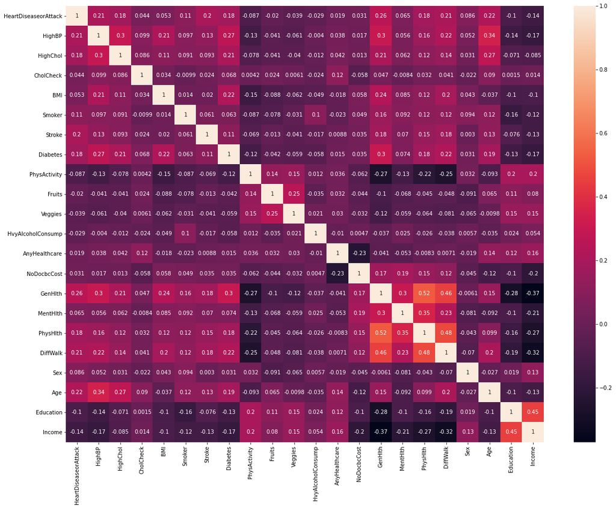

```python
# Calculem la correlació entre totes les variables

corr_df = data.corr(method='pearson')

plt.figure(figsize=(20, 15))
sns.heatmap(corr_df, annot=True)
plt.show()
```

# 3. Quina franja d’edat tenen les persones que han patit o pateixen alguna malaltia cardíaca?

```python
data_atac = data[(data["HeartDiseaseorAttack"]==1.0)]

data_atac.head()
```

|  | HeartDiseaseorAttack | HighBP | HighChol | CholCheck | BMI | Smoker | Stroke | Diabetes | PhysActivity | Fruits | Veggies | HvyAlcoholConsump | AnyHealthcare | NoDocbcCost | GenHlth | MentHlth | PhysHlth | DiffWalk | Sex | Age | Education | Income |
| --- | --- | --- | --- | --- | --- | --- | --- | --- | --- | --- | --- | --- | --- | --- | --- | --- | --- | --- | --- | --- | --- | --- |
| 8 | 1.0 | 1.0 | 1.0 | 1.0 | 30.0 | 1.0 | 0.0 | 2.0 | 0.0 | 1.0 | 1.0 | 0.0 | 1.0 | 0.0 | 5.0 | 30.0 | 30.0 | 1.0 | 0.0 | 9.0 | 5.0 | 1.0 |
| 20 | 1.0 | 1.0 | 1.0 | 1.0 | 22.0 | 0.0 | 1.0 | 0.0 | 0.0 | 1.0 | 0.0 | 0.0 | 1.0 | 0.0 | 3.0 | 30.0 | 0.0 | 1.0 | 0.0 | 12.0 | 4.0 | 4.0 |
| 26 | 1.0 | 1.0 | 1.0 | 1.0 | 37.0 | 1.0 | 1.0 | 2.0 | 0.0 | 0.0 | 1.0 | 0.0 | 1.0 | 0.0 | 5.0 | 0.0 | 0.0 | 1.0 | 1.0 | 10.0 | 6.0 | 5.0 |
| 27 | 1.0 | 1.0 | 1.0 | 1.0 | 28.0 | 1.0 | 0.0 | 2.0 | 0.0 | 0.0 | 1.0 | 0.0 | 1.0 | 0.0 | 4.0 | 0.0 | 0.0 | 0.0 | 1.0 | 12.0 | 2.0 | 4.0 |
| 47 | 1.0 | 1.0 | 1.0 | 1.0 | 25.0 | 1.0 | 0.0 | 0.0 | 0.0 | 1.0 | 1.0 | 0.0 | 1.0 | 0.0 | 2.0 | 1.0 | 0.0 | 0.0 | 1.0 | 10.0 | 4.0 | 7.0 |

```python
print("Quantitat de persones que han patit un atac {}".format(len(data_atac)))
```

```
Quantitat de persones que han patit un atac 23893
```

```python
data_no_atac = data[(data["HeartDiseaseorAttack"]==0.0)]

data_no_atac.head()
```

|  | HeartDiseaseorAttack | HighBP | HighChol | CholCheck | BMI | Smoker | Stroke | Diabetes | PhysActivity | Fruits | Veggies | HvyAlcoholConsump | AnyHealthcare | NoDocbcCost | GenHlth | MentHlth | PhysHlth | DiffWalk | Sex | Age | Education | Income |
| --- | --- | --- | --- | --- | --- | --- | --- | --- | --- | --- | --- | --- | --- | --- | --- | --- | --- | --- | --- | --- | --- | --- |
| 0 | 0.0 | 1.0 | 1.0 | 1.0 | 40.0 | 1.0 | 0.0 | 0.0 | 0.0 | 0.0 | 1.0 | 0.0 | 1.0 | 0.0 | 5.0 | 18.0 | 15.0 | 1.0 | 0.0 | 9.0 | 4.0 | 3.0 |
| 1 | 0.0 | 0.0 | 0.0 | 0.0 | 25.0 | 1.0 | 0.0 | 0.0 | 1.0 | 0.0 | 0.0 | 0.0 | 0.0 | 1.0 | 3.0 | 0.0 | 0.0 | 0.0 | 0.0 | 7.0 | 6.0 | 1.0 |
| 2 | 0.0 | 1.0 | 1.0 | 1.0 | 28.0 | 0.0 | 0.0 | 0.0 | 0.0 | 1.0 | 0.0 | 0.0 | 1.0 | 1.0 | 5.0 | 30.0 | 30.0 | 1.0 | 0.0 | 9.0 | 4.0 | 8.0 |
| 3 | 0.0 | 1.0 | 0.0 | 1.0 | 27.0 | 0.0 | 0.0 | 0.0 | 1.0 | 1.0 | 1.0 | 0.0 | 1.0 | 0.0 | 2.0 | 0.0 | 0.0 | 0.0 | 0.0 | 11.0 | 3.0 | 6.0 |
| 4 | 0.0 | 1.0 | 1.0 | 1.0 | 24.0 | 0.0 | 0.0 | 0.0 | 1.0 | 1.0 | 1.0 | 0.0 | 1.0 | 0.0 | 2.0 | 3.0 | 0.0 | 0.0 | 0.0 | 11.0 | 5.0 | 4.0 |

```python
print("Quantitat de persones que no han patit un atac {}".format(len(data_no_atac)))
```

```
Quantitat de persones que no han patit un atac 229787
```

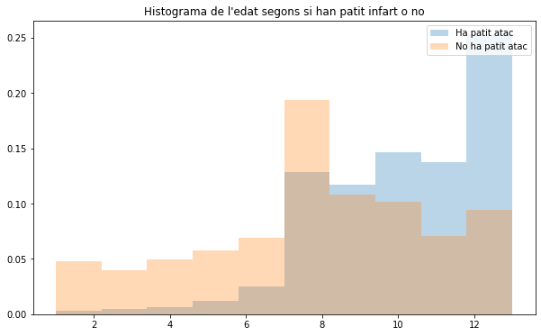

```python
plt.figure(figsize=(10, 6))
plt.hist(data_atac['Age'], density= 'TRUE', alpha=0.3, histtype='stepfilled', label="Ha patit atac")
plt.hist(data_no_atac['Age'], density= 'TRUE', alpha=0.3, histtype='stepfilled', label="No ha patit atac")
plt.title("Histograma de l'edat segons si han patit infart o no")
plt.legend()
plt.show()
```

# 4. La majoria d’individus que han patit o pateixen una malaltia cardíaca són homes o dones?

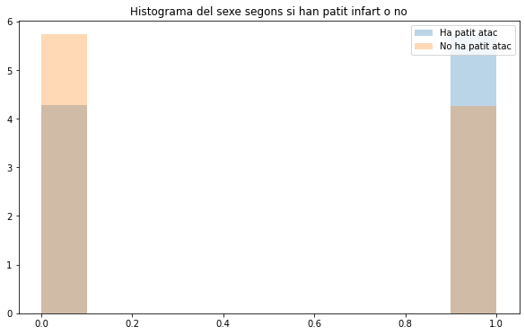

```python
plt.figure(figsize=(10, 6))
plt.hist(data_atac['Sex'], density= 'TRUE', alpha=0.3, histtype='stepfilled', label="Ha patit atac")
plt.hist(data_no_atac['Sex'], density= 'TRUE', alpha=0.3, histtype='stepfilled', label="No ha patit atac")
plt.title("Histograma del sexe segons si han patit infart o no")
plt.legend()
plt.show()
```

# 5. Quins hàbits tenen els individus que pateixen o han patit una malaltia cardíaca? Fumen, consumeixen alcohol, mengen fruita i verdura, fan activitat física? Quin índex de massa corporal tenen?

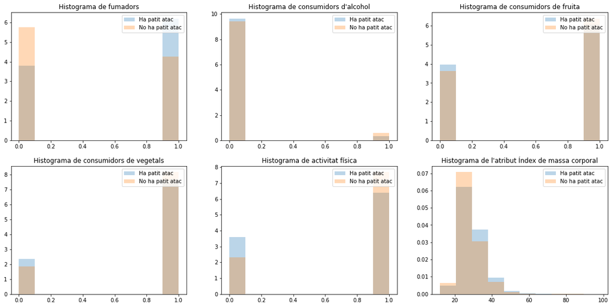

```python
plt.figure(figsize=(20, 15))

plt.subplot(3, 3, 1)
plt.hist(data_atac['Smoker'], density= 'TRUE', alpha=0.3, histtype='stepfilled', label="Ha patit atac")
plt.hist(data_no_atac['Smoker'], density= 'TRUE', alpha=0.3, histtype='stepfilled', label="No ha patit atac")
plt.title("Histograma de fumadors")
plt.legend()

plt.subplot(3, 3, 2)
plt.hist(data_atac['HvyAlcoholConsump'], density= 'TRUE', alpha=0.3, histtype='stepfilled', label="Ha patit atac")
plt.hist(data_no_atac['HvyAlcoholConsump'], density= 'TRUE', alpha=0.3, histtype='stepfilled', label="No ha patit atac")
plt.title("Histograma de consumidors d'alcohol")
plt.legend()

plt.subplot(3, 3, 3)
plt.hist(data_atac['Fruits'], density= 'TRUE', alpha=0.3, histtype='stepfilled', label="Ha patit atac")
plt.hist(data_no_atac['Fruits'], density= 'TRUE', alpha=0.3, histtype='stepfilled', label="No ha patit atac")
plt.title("Histograma de consumidors de fruita")
plt.legend()

plt.subplot(3, 3, 4)
plt.hist(data_atac['Veggies'], density= 'TRUE', alpha=0.3, histtype='stepfilled', label="Ha patit atac")
plt.hist(data_no_atac['Veggies'], density= 'TRUE', alpha=0.3, histtype='stepfilled', label="No ha patit atac")
plt.title("Histograma de consumidors de vegetals")
plt.legend()

plt.subplot(3, 3, 5)
plt.hist(data_atac['PhysActivity'], density= 'TRUE', alpha=0.3, histtype='stepfilled', label="Ha patit atac")
plt.hist(data_no_atac['PhysActivity'], density= 'TRUE', alpha=0.3, histtype='stepfilled', label="No ha patit atac")
plt.title("Histograma de activitat física")
plt.legend()

plt.subplot(3, 3, 6)
plt.hist(data_atac['BMI'], density= 'TRUE', alpha=0.3, histtype='stepfilled', label="Ha patit atac")
plt.hist(data_no_atac['BMI'], density= 'TRUE', alpha=0.3, histtype='stepfilled', label="No ha patit atac")
plt.title("Histograma de l'atribut Índex de massa corporal")
plt.legend()

plt.show()
```

# 6. Les persones que han patit o pateixen una malaltia cardíaca han patit també un ictus?

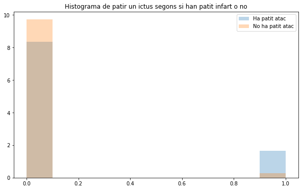

```python
plt.figure(figsize=(10, 6))
plt.hist(data_atac['Stroke'], density= 'TRUE', alpha=0.3, histtype='stepfilled', label="Ha patit atac")
plt.hist(data_no_atac['Stroke'], density= 'TRUE', alpha=0.3, histtype='stepfilled', label="No ha patit atac")
plt.title("Histograma de patir un ictus segons si han patit infart o no")
plt.legend()
plt.show()
```

# 7. Les persones que han patit o pateixen una malaltia cardíaca tenen diabetis?

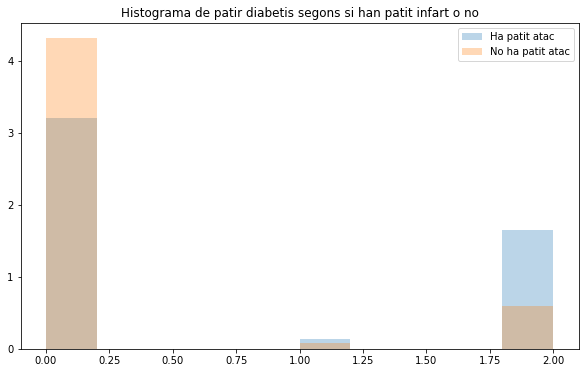

```python
plt.figure(figsize=(10, 6))
plt.hist(data_atac['Diabetes'], density= 'TRUE', alpha=0.3, histtype='stepfilled', label="Ha patit atac")
plt.hist(data_no_atac['Diabetes'], density= 'TRUE', alpha=0.3, histtype='stepfilled', label="No ha patit atac")
plt.title("Histograma de patir diabetis segons si han patit infart o no")
plt.legend()
plt.show()
```

# 8. Les persones que han patit o pateixen una malaltia cardíaca tenen el colesterol alt?

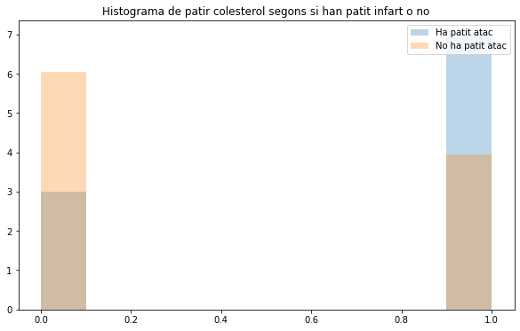

```python
plt.figure(figsize=(10, 6))
plt.hist(data_atac['HighChol'], density= 'TRUE', alpha=0.3, histtype='stepfilled', label="Ha patit atac")
plt.hist(data_no_atac['HighChol'], density= 'TRUE', alpha=0.3, histtype='stepfilled', label="No ha patit atac")
plt.title("Histograma de patir colesterol segons si han patit infart o no")
plt.legend()
plt.show()
```

# 9. La salut física i mental té alguna relació amb el fet de patir una malaltia cardíaca?

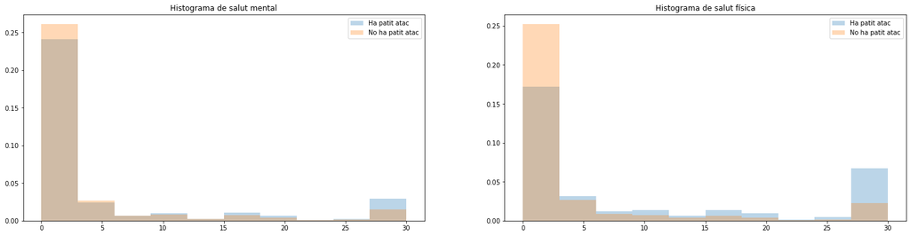

```python
plt.figure(figsize=(25, 6))

plt.subplot(1, 2, 1)
plt.hist(data_atac['MentHlth'], density= 'TRUE', alpha=0.3, histtype='stepfilled', label="Ha patit atac")
plt.hist(data_no_atac['MentHlth'], density= 'TRUE', alpha=0.3, histtype='stepfilled', label="No ha patit atac")
plt.title("Histograma de salut mental")
plt.legend()

plt.subplot(1, 2, 2)
plt.hist(data_atac['PhysHlth'], density= 'TRUE', alpha=0.3, histtype='stepfilled', label="Ha patit atac")
plt.hist(data_no_atac['PhysHlth'], density= 'TRUE', alpha=0.3, histtype='stepfilled', label="No ha patit atac")
plt.title("Histograma de salut física")
plt.legend()


plt.show()
```

# 10. La salut física i mental té alguna relació amb els hàbits dels individus?

```python
data_10 = data[["Smoker", "PhysActivity", "Fruits", "Veggies", "HvyAlcoholConsump", "GenHlth", "MentHlth", "PhysHlth", "DiffWalk"]]
```

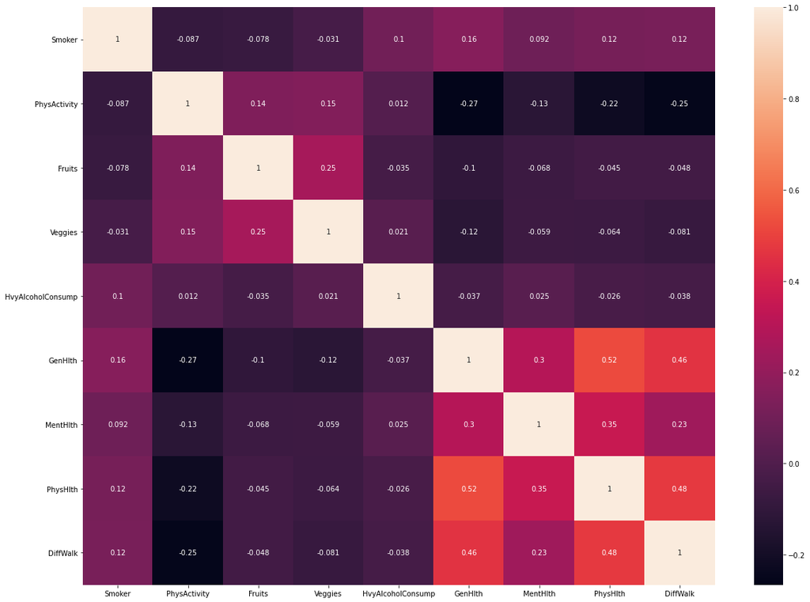

```python
# Calculem la correlació entre totes les variables

corr_df = data_10.corr(method='pearson')

plt.figure(figsize=(20, 15))
sns.heatmap(corr_df, annot=True)
plt.show()
```

# 11. Quina relació hi ha entre els hàbits, la salut mental i física i els ingressos?

```python
data_11 = data[["Smoker", "PhysActivity", "Fruits", "Veggies", "HvyAlcoholConsump", "GenHlth", "MentHlth", "PhysHlth", "DiffWalk", "Education", "Income"]]
```

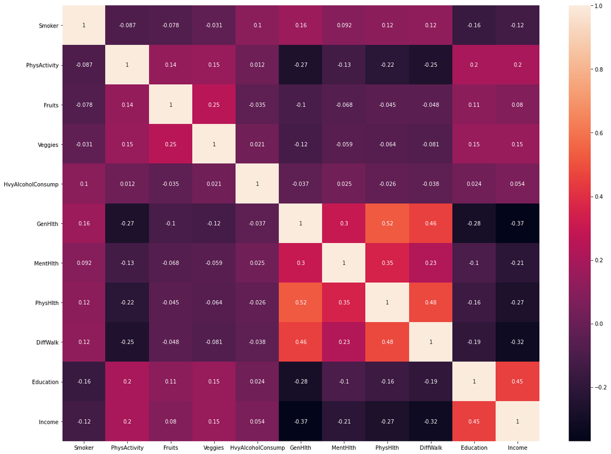

```python
# Calculem la correlació entre totes les variables

corr_df = data_11.corr(method='pearson')

plt.figure(figsize=(20, 15))
sns.heatmap(corr_df, annot=True)
plt.show()
```